# Trabajo Final

Introducción al Data Mining Maestría en Explotación de Datos y Gestión del Conocimiento Universidad Austral

Franco Lianza

# 1 Introduccion

#### ESTUDIO DE PREVENCIÓN CARDIOVASCULAR EN EL ADULTO MAYOR

El incremento de la expectativa de vida ha generado un aumento en la incidencia de enfermedades cardiovasculares y neurológicas. En los adultos mayores es donde se conjugan diversas patologías con alta morbi-mortalidad requiriendo gran cantidad de recursos materiales y humanos. Dado que, la determinación en análisis sanguíneos de rutina permite la detección de alteraciones que en determinadas circunstancias podrían progresar a patologías definidas con serias repercusiones cardiovasculares en este grupo poblacional, se estudió la frecuencia en adultos mayores de diversas patologías subclínicas y la asociación entre los factores de riesgo cardiovascular y dichas patologías subclínicas.

Se cuenta con información de 68 personas de ambos sexos mayores de 60 años, a quienes se les midieron las siguientes variables (disponibles en el archivo ‘cardio.xls’):

| Variable | Descripcion | Medidas |
| --- | --- | --- |
| sexo | Sexo del paciente | 0: Femenino, 1: Masculino |
| imc | Índice de masa corporal | valor expresado en $[kg/m^2]$ |
| perimetro_abdo | Perímetro abdominal | valor expresado en $[cm]$ |
| hto | Hematocrito | valor expresado en $\%$ |
| glicemia | Glicemia | valor expresado en $[mg/dL]$ |
| ct | Colesterol Total | valor expresado en $[mg/dL]$ |
| hdl | Colesterol HDL | valor expresado en $[mg/dL]$ |
| tgd | Triglicéridos | valor expresado en $[mg/dL]$ |

```r
cardio %>%
  format_table('Datos del dataset cardio.xlsx')
```

|  | id | sexo | imc | perimetro_abdo | hto | glicemia | ct | hdl | tgd |
| --- | --- | --- | --- | --- | --- | --- | --- | --- | --- |
| 1 | 1 | F | 27.8459937565036 | 84 | 35 | 1.18 | 225 | 75 | 2.1 |
| 2 | 2 | M | 29.5891985061764 | 104.5 | 43.5 | 0.93 | 293 | 37 | 5.21 |
| 3 | 3 | F | 24.1313779626376 | 91.5 | 39.1 | 0.87 | 197 | 54 | 1.3 |
| 4 | 4 | F | 31.2973739547166 | 95 | 42.8 | 0.73 | 282 | 57 | 1.18 |
| 5 | 5 | M | 25.0314414377865 | 90 | 41.1 | 0.98 | 154 | 24 | 1.26 |
| 6 | 6 | F | 31.404958677686 | 106 | 40.6 | 0.99 | 222 | 58 | 1.09 |
| 7 | 7 | F | 23.8086700849797 | 94 | 38.5 | 1.33 | 230 | 60 | 0.99 |
| 8 | 8 | F | 30.6703397612489 | 113 | 41.6 | 0.83 | 195 | 60 | 1.15 |
| 9 | 9 | F | 27.6261808875005 | 93 | 43.9 | 0.96 | 220 | 57 | 1.44 |
| 10 | 10 | M | 28.5585141354372 | 89 | 35.4 | 1.15 | 193 | 54 | 0.92 |

[output cut: 58 more lines]

# 2 Analisis exploratorio

*Describa la distribución univariada de las variables presente en el conjunto de datos. ¿Se evidencian outliers en alguna de ellas?*

Comenzaremos analizando los estadisticos descriptivos de cada una de las variables.

```r
summary(cardio)
```

```
##        id         sexo                imc        perimetro_abdo
##  1      : 1   Length:68          Min.   :21.91   Min.   : 75.00
##  2      : 1   Class :character   1st Qu.:25.78   1st Qu.: 89.75
##  3      : 1   Mode  :character   Median :28.16   Median : 99.00
##  4      : 1                      Mean   :29.27   Mean   :100.40
##  5      : 1                      3rd Qu.:31.25   3rd Qu.:106.50
##  6      : 1                      Max.   :45.54   Max.   :139.00
##  (Other):62
##       hto           glicemia            ct             hdl
##  Min.   :28.20   Min.   :0.6800   Min.   :143.0   Min.   :24.00
##  1st Qu.:38.88   1st Qu.:0.8775   1st Qu.:185.5   1st Qu.:46.75
##  Median :41.40   Median :0.9600   Median :207.5   Median :57.50
##  Mean   :41.96   Mean   :0.9937   Mean   :212.9   Mean   :57.12
##  3rd Qu.:44.52   3rd Qu.:1.0625   3rd Qu.:234.8   3rd Qu.:65.00
##  Max.   :52.20   Max.   :1.6500   Max.   :296.0   Max.   :93.00
##
##       tgd
##  Min.   :0.540
##  1st Qu.:1.010
##  Median :1.150
##  Mean   :1.356
##  3rd Qu.:1.460
##  Max.   :5.210
##
```

A simple vista se puede observar que la variable `tgd` posee outliers, ya que el valor maximo de dicha variable es `5.210` y su 3er cuartil es de `1.460`.

Revisaremos el comportamiento de cada una de las variables a continuacion.

## 2.1 Indice de masa corporal (imc)

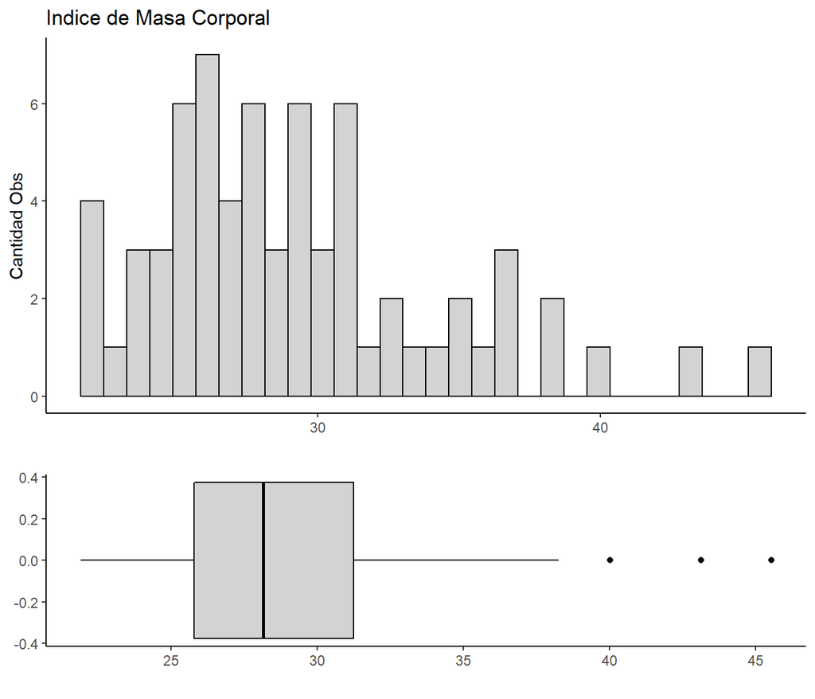

Figure 2.1: Distribucion de la variable Indice de Masa Corporal (imc)

```r
plot_continuous_variable('imc', 'Indice de Masa Corporal')
```

La variable `imc` presenta 3 valores extremos segun el boxplot.

Su media se encuentra en `29.27` y es asimetrica hacia la derecha.

## 2.2 Perimetro abdominal

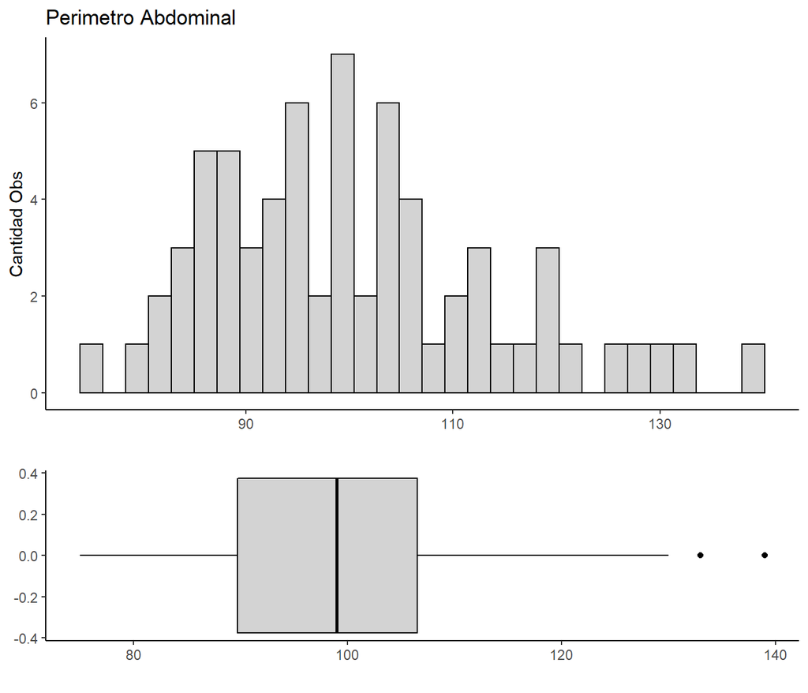

Figure 2.2: Distribucion de la variable Perimetro Abdominal (perimetro_abdo)

```r
plot_continuous_variable('perimetro_abdo', 'Perimetro Abdominal')
```

La variable `perimetro_abdo` presenta 2 valores extremos segun el boxplot.

La media se encuentra en `100.40` y es asimetrica hacia la derecha.

## 2.3 Hematocrito

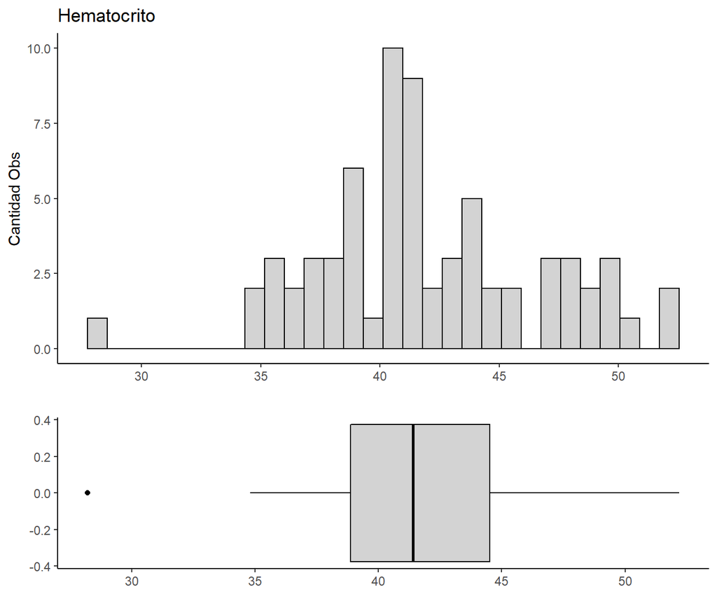

Figure 2.3: Distribucion de la variable Hematocrito (hto)

```r
plot_continuous_variable('hto', 'Hematocrito')
```

La variable `hto` presenta un valor extremo segun el boxplot (28.20). Dicho valor se encuentra muy alejado del resto de los datos.

La media se encuentra situada en `41.96`.

## 2.4 Glicemia

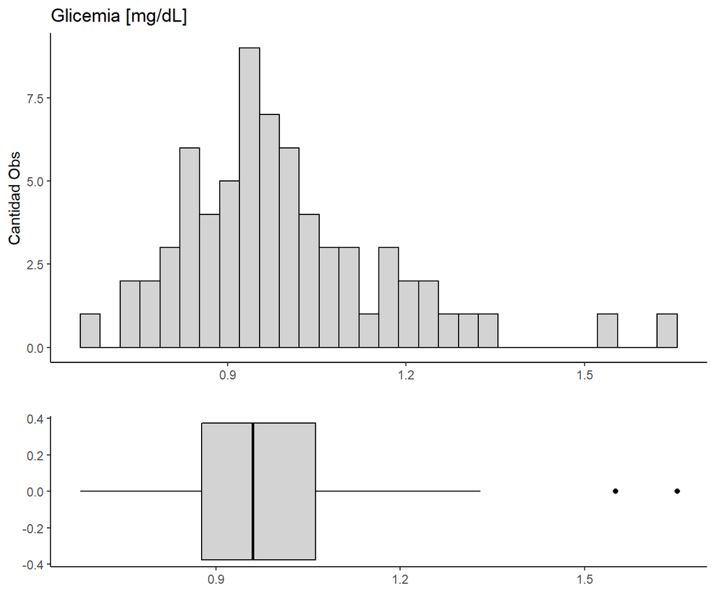

Figure 2.4: Distribucion de la variable Glicemia (glicemia)

```r
plot_continuous_variable('glicemia', 'Glicemia [mg/dL]')
```

La variable `glicemia` presenta dos valores extremos segun el boxplot.

La media se encuentra en `0.99` y es asimetrica hacia la derecha.

## 2.5 Colesterol Total

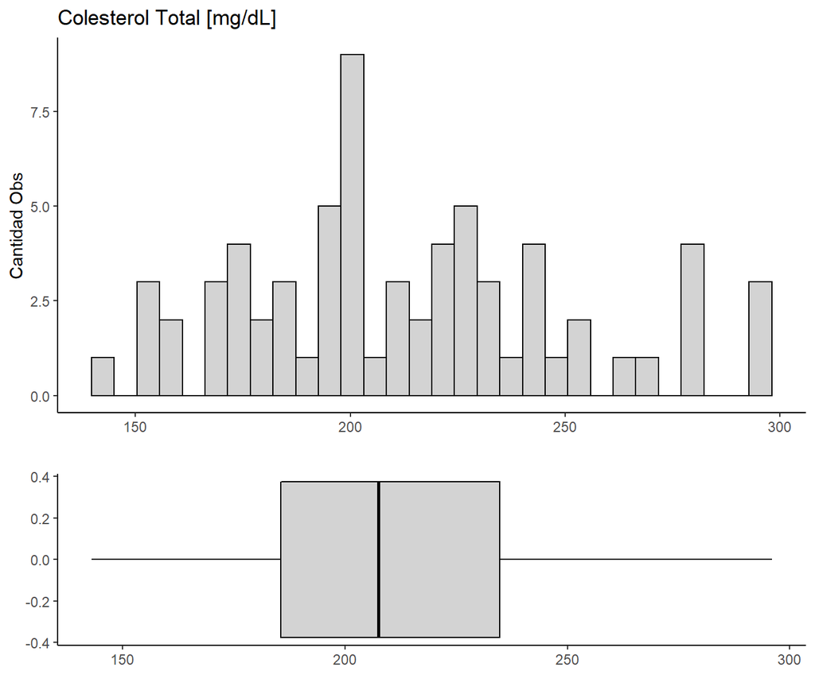

Figure 2.5: Distribucion de la variable Colesterol Total (ct)

```r
plot_continuous_variable('ct', 'Colesterol Total [mg/dL]')
```

La variable `ct` no presenta valores extremos.

La media se encuentra en `212.9`. Parece estar distribuida de manera bastante “uniforme”.

## 2.6 Colesterol HDL

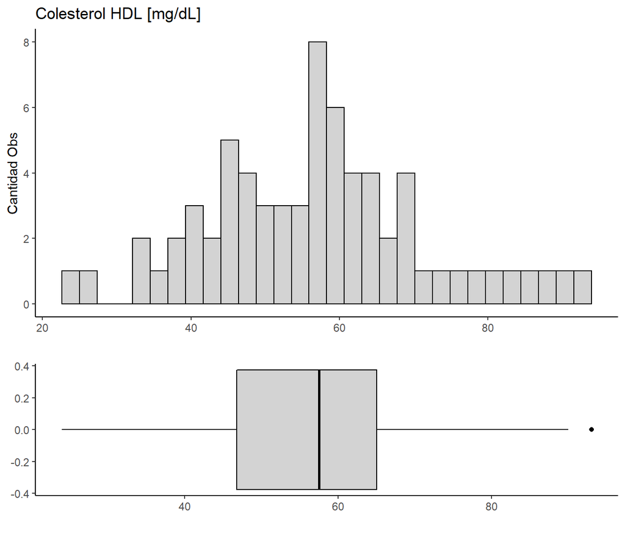

Figure 2.6: Distribucion de la variable Colesterol HDL (hdl)

```r
plot_continuous_variable('hdl', 'Colesterol HDL [mg/dL]')
```

La variable `hdl` presenta un valor extremo segun el boxplot.

La media se encuentra en `57.12`.

## 2.7 Triglicéridos

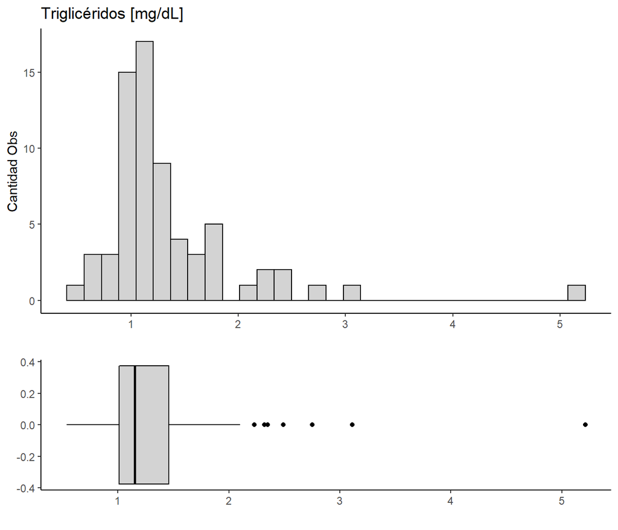

Figure 2.7: Distribucion de la variable Triglicéridos (tgd)

```r
plot_continuous_variable('tgd', 'Triglicéridos [mg/dL]')
```

La variable `tgd` presenta varios valores extremos segun el boxplot, todos hacia la derecha.

La media se encuentra en `1.356`.

Dichas observaciones son las siguientes:

|  | id | sexo | imc | perimetro_abdo | hto | glicemia | ct | hdl | tgd |
| --- | --- | --- | --- | --- | --- | --- | --- | --- | --- |
| 1 | 2 | M | 29.5891985061764 | 104.5 | 43.5 | 0.93 | 293 | 37 | 5.21 |
| 2 | 14 | F | 24.9895876718034 | 94 | 41.6 | 1.18 | 215 | 79 | 2.75 |
| 3 | 36 | F | 28.5714285714286 | 86 | 34.8 | 0.75 | 264 | 56 | 2.49 |
| 4 | 39 | M | 30.718537414966 | 104 | 52.2 | 1.06 | 171 | 54 | 3.11 |
| 5 | 44 | M | 29.3360954258412 | 100 | 45.2 | 0.83 | 227 | 34 | 2.32 |
| 6 | 53 | F | 29.7355379150037 | 104 | 40.2 | 0.81 | 221 | 70 | 2.35 |
| 7 | 57 | M | 26.7208349848064 | 85 | 47.6 | 0.9 | 237 | 41 | 2.23 |

Tendremos que tener en cuenta estas observaciones para las acciones que tomemos de aca en adelante.

## 2.8 Sexo

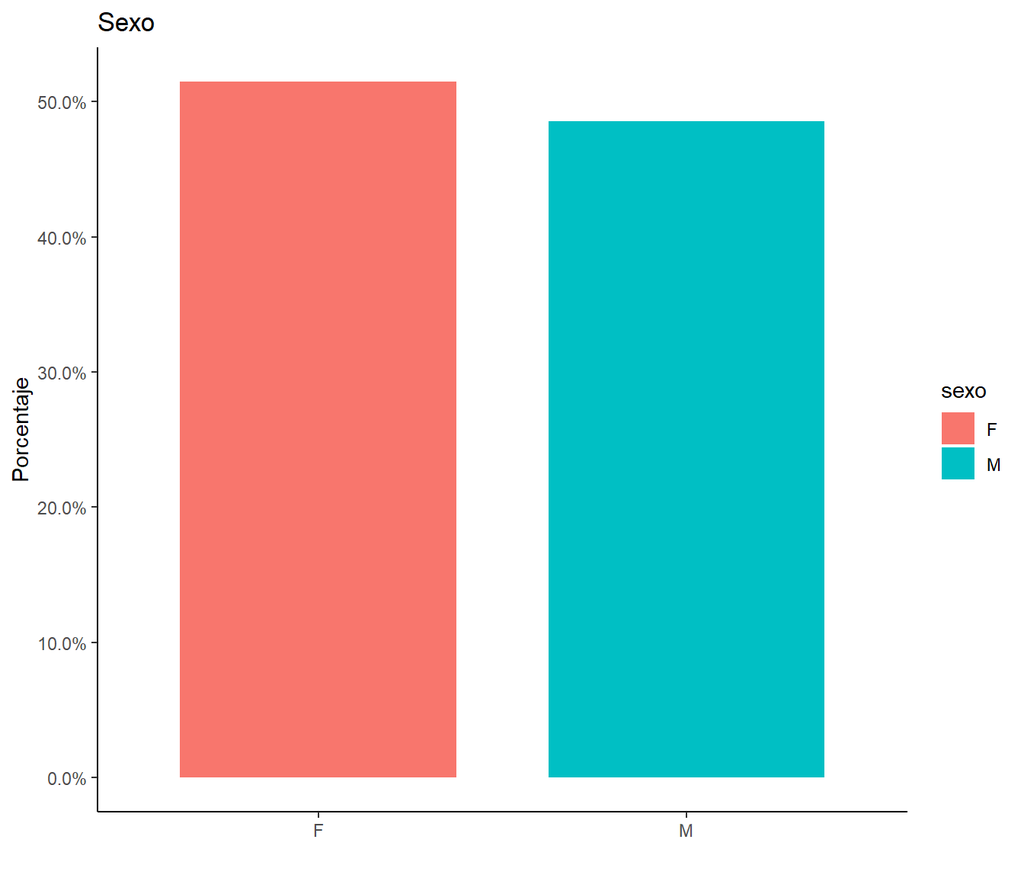

Figure 2.8: Distribucion de la variable Sexo (sexo)

```r
cardio %>%
  ggplot() +
  aes(x = sexo, y = ..count.. / sum(..count..), fill = sexo) +
  geom_bar(width = 0.75) +
  scale_y_continuous(labels = scales::percent) +
  labs(x = '', y = 'Porcentaje', title = 'Sexo')
```

La variable sexo parece estar equilibrada en femenino y masculino.

# 3 Matriz de Correlacion

*Calcule e interprete la matriz de correlaciones.*

```r
cor(cardio_numericas)
```

```
##                        imc perimetro_abdo         hto    glicemia          ct
## imc             1.00000000     0.81806342  0.18816144  0.18542780  0.12777407
## perimetro_abdo  0.81806342     1.00000000  0.23087883  0.14548536  0.07602887
## hto             0.18816144     0.23087883  1.00000000  0.12610033  0.05125077
## glicemia        0.18542780     0.14548536  0.12610033  1.00000000 -0.05068732
## ct              0.12777407     0.07602887  0.05125077 -0.05068732  1.00000000
## hdl            -0.22154444    -0.19256276 -0.14354171 -0.11560888  0.08052329
## tgd            -0.02343886    -0.01638575  0.14308745 -0.01730835  0.29841518
##                        hdl         tgd
## imc            -0.22154444 -0.02343886
## perimetro_abdo -0.19256276 -0.01638575
## hto            -0.14354171  0.14308745
## glicemia       -0.11560888 -0.01730835
## ct              0.08052329  0.29841518
## hdl             1.00000000 -0.24970885
## tgd            -0.24970885  1.00000000
```

Visualmente:

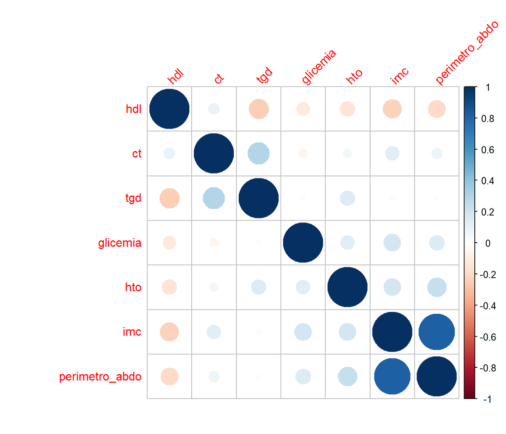

Figure 3.1: Matriz de Correlaciones

```r
cardio_numericas %>%
  cor() %>%
  corrplot(order = "hclust", tl.srt = 45)
```

De lo anterior podemos ver que:

- La variable `imc` y `perimetro_abdo` se encuentran altamente correladas de manera positiva, siendo su indice `0.82`. Esto significa que cuando aumenta el valor de algunas de ellas, la otra aumenta propocionalmente.
- La variable `hdl` se encuentra levemente correlada de forma negativa con `tgd` siendo su indice `-0.25`.
- La variable `tgd` se encuentra levemente correlada de forma positiva con `ct` siendo su indice `0.30`.

Revisaremos el grafico de puntos entre `imc` y `perimetro_abdo`.

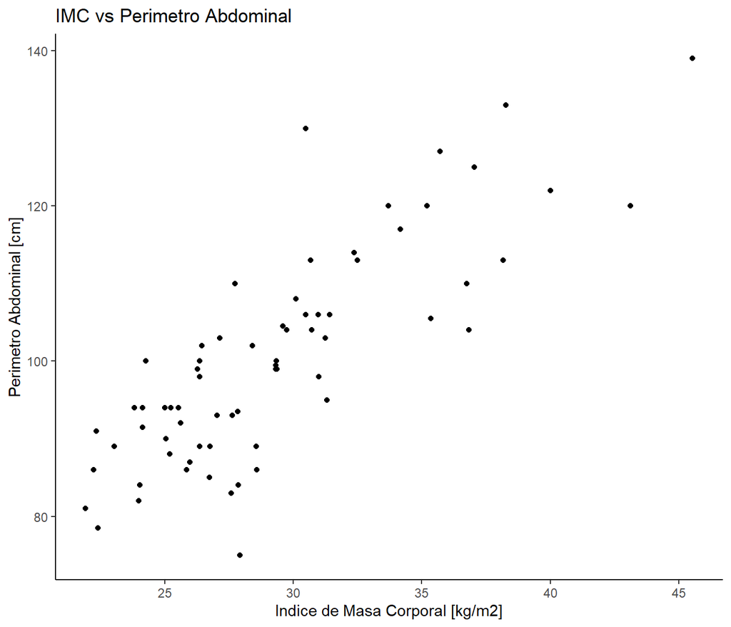

Figure 3.2: Scatter plot de Indice de Masa Corporal y Perimetro Abdominal

```r
ggplot(cardio) +
  aes(x = imc, y = perimetro_abdo) +
  geom_point() +
  labs(x = 'Indice de Masa Corporal [kg/m2]', y = 'Perimetro Abdominal [cm]', title = 'IMC vs Perimetro Abdominal')
```

Es logico que estas variables esten correladas, debido a que si una persona tiene un mayor perimetro abdominal, es esperable que su peso sea mayor. Como el imc se calcula de la forma $IMC=Peso/Estatura^2$ entonces, a mayor peso mayor imc.

# 4 PCA

*Realice un análisis de componentes principales.*

¿Qué porcentaje de la variabilidad total logran explicar las dos primeras componentes?

¿Es posible realizar una interpretación sobre los componentes? ¿Cuál?

¿Logran esas componentes diferenciar a los pacientes según el sexo?

El PCA nos permite transformar un conjunto de variables numericas correladas en otro no correlado.

En este caso vamos a decirle a PCA que estandarice las variables debido a la alta variabilidad de los datos y a sus diferentes unidades de medida. A su vez, en este contexto no es representativa la diferencia entre ellas, por ejemplo `hto` medido en $%$ y `perimetro_abdo` medido en `cm`.

Aplicaremos PCA teniendo en cuenta lo dicho y utilizando todas las variables excepto `sexo` debido a que es categorica.

## 4.1 Sin tratamiento de outliers

```r
pca_cardio <- prcomp(cardio_numericas, scale = TRUE)

summary(pca_cardio)
```

```
## Importance of components:
##                           PC1    PC2    PC3    PC4    PC5     PC6     PC7
## Standard deviation     1.4542 1.1563 1.0511 0.9536 0.9164 0.72009 0.41904
## Proportion of Variance 0.3021 0.1910 0.1578 0.1299 0.1200 0.07408 0.02508
## Cumulative Proportion  0.3021 0.4931 0.6509 0.7809 0.9008 0.97492 1.00000
```

Podemos observar que con las dos primeras componentes `PC1` y `PC2` explicamos el `0.4931` de la varianza total.

Obtenemos aproximadamente un 80% de la variacion total en la `PC4`.

Revisaremos sus eigenvectors para interpretar cada una de ellas.

```r
pca_cardio$rotation
```

```
##                       PC1        PC2        PC3         PC4         PC5
## imc             0.6041206 -0.1833581  0.2489710 -0.13225519  0.08216907
## perimetro_abdo  0.5986670 -0.1956319  0.2410856 -0.14680743 -0.02356979
## hto             0.3128296  0.1784329 -0.2338474  0.40068151 -0.79883373
## glicemia        0.2383173 -0.1689521 -0.3914805  0.70194715  0.51605843
## ct              0.1226601  0.5398182  0.5547835  0.25742111  0.21102916
## hdl            -0.3056453 -0.1994744  0.5827381  0.48700827 -0.16591853
## tgd             0.1162502  0.7324829 -0.1567837 -0.06509983  0.12719597
##                        PC6         PC7
## imc            -0.08892621  0.71223628
## perimetro_abdo -0.20743229 -0.69286915
## hto             0.12239964  0.04418155
## glicemia       -0.02569744 -0.04118981
## ct              0.51958868 -0.07067352
## hdl            -0.50989288  0.05010472
## tgd            -0.63518406  0.03870380
```

A partir de la salida anterior, podemos concluir que:

- La `PC1` explica mayormente las variables `imc` y `perimetro_abdo` siendo sus valores `0.6041206` y `0.5986670` respectivamente. Esto era esperable, ya que vimos en la matriz de correlaciones que dichas variables estaban altamente correladas.
- La `PC2` explica mayormente las variables `ct` y `tgd` siendo sus valores `0.5398182` y `0.7324829` respectivamente. Esto tambien era esperable, ya que vimos en la matriz de correlaciones que dichas variables estaban levemente correladas.
- La `PC3` explica mayormente las variables `ct` y `hdl` siendo sus valores `0.5547835` y `0.5827381` respectivamente.
- La `PC4` explica mayormente las variables `glicemia`, `hdl` y `hto`.

Realizaremos un biplot entre `PC1` y `PC2` para visualizarlo mejor.

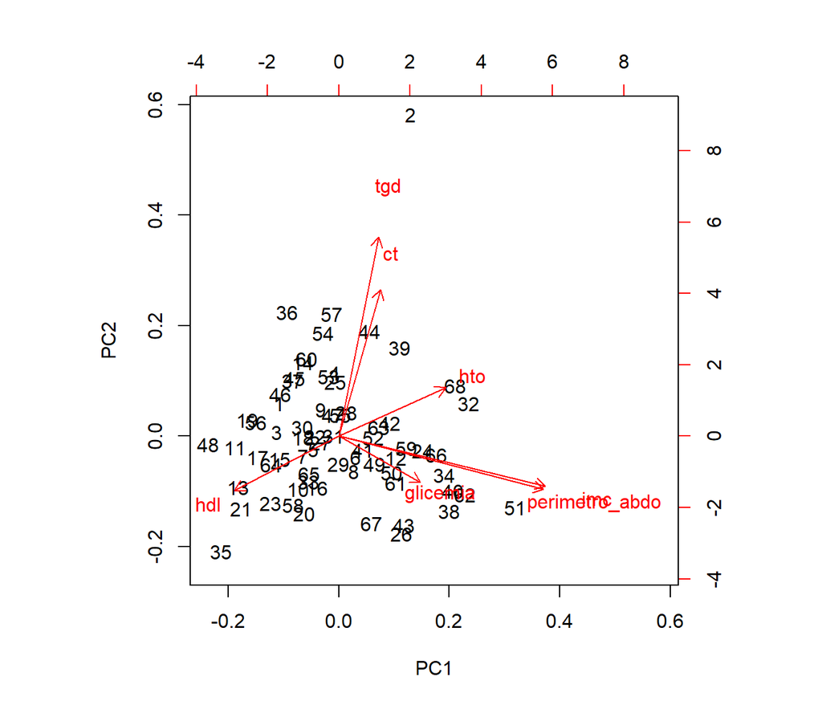

Figure 4.1: Biplot de PC1 y PC2 sin tratamiento de outliers

```r
biplot(pca_cardio)
```

Como mencionabamos anteriormente, los vectores de `imc` y `perimetro_abdo` son aproximadamente iguales. Esto significa que ambas aportan “la misma informacion” a la variabilidad de los datos. Algo similar ocurre con `tgd` y `ct` pero en menor medida.

En el grafico podemos tambien observar que:

- El individuo 2 posee alto `tgd` y `ct`. Se encuentra muy alejado de los demas, por lo que es probable que sea un outlier.
- Los individuos 68 y 32 son los que tienen mas `hto`.
- El individuo 51 posee alto `imc` y `perimetro_abdo`.
- El individuo 35 es el que posee mayor `hdl`.

Sin embargo, remitiendonos al analisis exploratorio, habian algunos valores extremos en la variable `tgd`. Revisaremos la contribucion de cada observacion al PCA realizado sobre las primeras dos componentes.

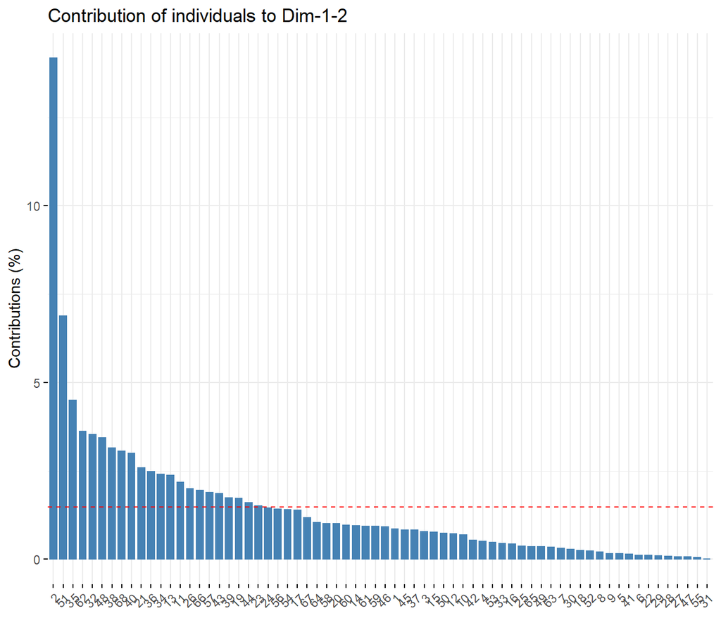

Figure 4.2: Contribucion de los individuos a PC1 y PC2 sin tratamiento de outliers

```r
fviz_contrib(pca_cardio, choice = "ind", axes = 1:2)
```

Como era de esperarse, podemos observar que el individuo 2 es el que mayor contribuye al PCA. Dicho individuo es un outlier para la variable `tgd`.

El PCA es una tecnica suceptible a los valores extremos, por lo que repetiremos el analisis eliminando dicha observacion.

## 4.2 Con tratamiento de outliers

```r
cardio_numericas_pca <- cardio_numericas[-c(2), ]

pca_cardio <- prcomp(cardio_numericas_pca, scale = TRUE)

summary(pca_cardio)
```

```
## Importance of components:
##                           PC1    PC2    PC3    PC4    PC5     PC6     PC7
## Standard deviation     1.4500 1.1114 1.0736 0.9535 0.9110 0.77167 0.41847
## Proportion of Variance 0.3004 0.1764 0.1646 0.1299 0.1186 0.08507 0.02502
## Cumulative Proportion  0.3004 0.4768 0.6415 0.7713 0.8899 0.97498 1.00000
```

Las nuevas componentes explican la varianza de una manera similar al analisis anterior.

```r
pca_cardio$rotation
```

```
##                        PC1        PC2         PC3        PC4         PC5
## imc             0.61294356 -0.2220894  0.14898163 -0.1225069 -0.09733321
## perimetro_abdo  0.60603654 -0.2467213  0.12681973 -0.1432300  0.02103051
## hto             0.30903910  0.3622752 -0.04278362  0.2364141  0.82364467
## glicemia        0.25140859  0.0522342 -0.32981724  0.8291612 -0.36899576
## ct              0.08695398  0.2391240  0.77679262  0.1561632 -0.24945714
## hdl            -0.29539869 -0.3186812  0.48997356  0.4269314  0.27721306
## tgd             0.05905153  0.7727193  0.08735279 -0.1200827 -0.19094396
##                         PC6          PC7
## imc             0.150713767  0.711044759
## perimetro_abdo  0.225534511 -0.695659492
## hto            -0.186455337  0.048716543
## glicemia        0.004752461 -0.039963371
## ct             -0.490762329 -0.066245585
## hdl             0.556667164  0.045955789
## tgd             0.583871023  0.001561058
```

Repitiendo el bitplot anterior:

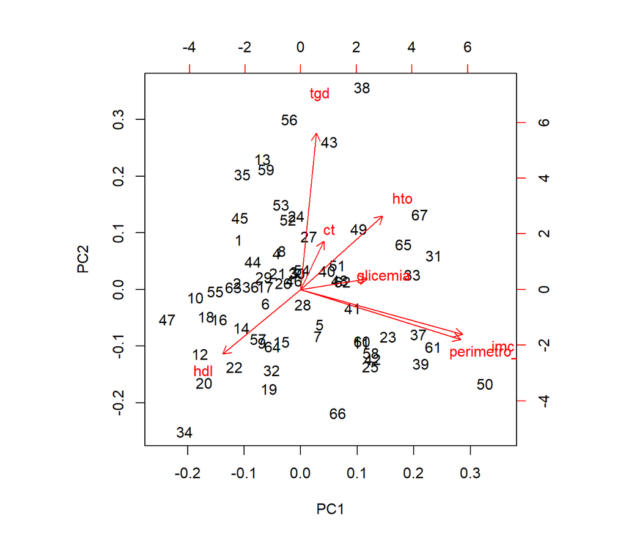

Figure 4.3: Biplot de PC1 y PC2 con tratamiento de outliers

```r
biplot(pca_cardio)
```

Y revisando nuevamente la contribucion de cada individuo al PCA realizado:

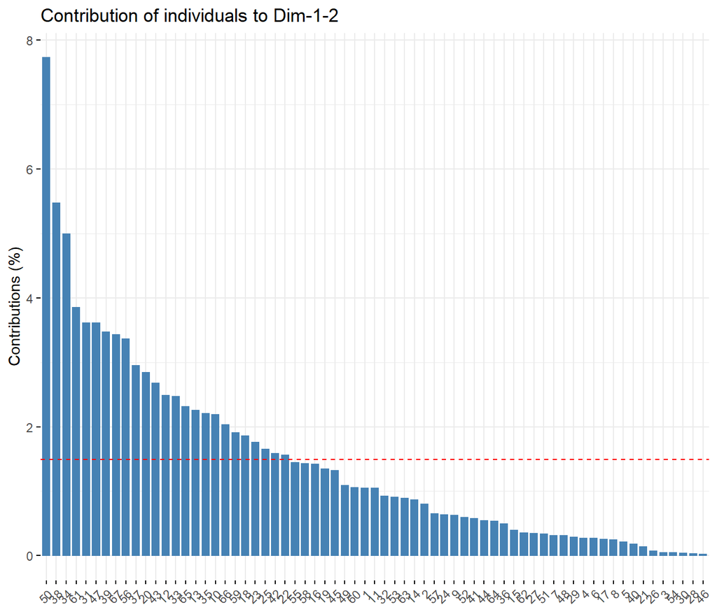

Figure 4.4: Contribucion de los individuos a PC1 y PC2 con tratamiento de outliers

```r
fviz_contrib(pca_cardio, choice = "ind", axes = 1:2)
```

Ahora podemos quedarnos seguros de que el PCA que realizamos no esta siendo “absorbido” por el outlier 2.

Continuaremos a analizar que sucede con la variable sexo.

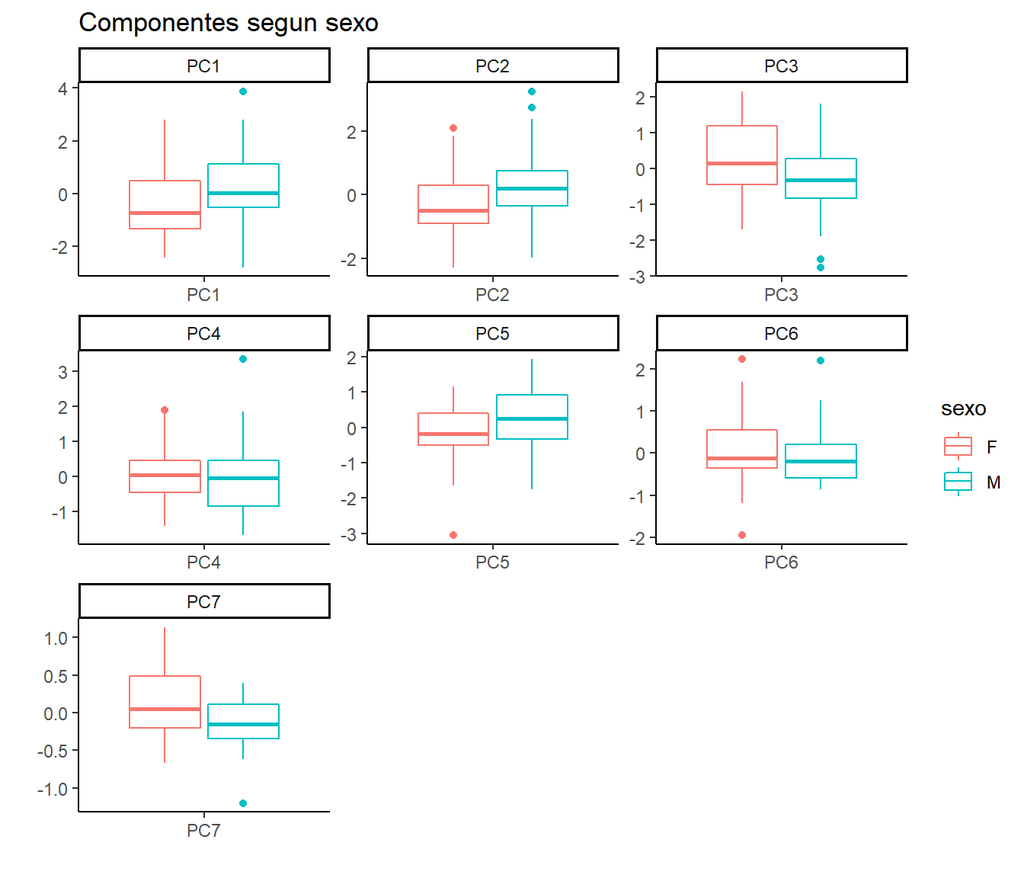

Figure 4.5: PCs segun sexo

```r
cardio_pca <- data.frame(pca_cardio$x)
cardio_pca$sexo <- cardio[-c(2), ]$sexo

ggplot(melt(cardio_pca)) +
  aes(x = variable, y = value, color = sexo) +
  geom_boxplot() +
  labs(x = '', y = '', title = 'Componentes segun sexo') +
  facet_wrap(~variable, scale = 'free')
```

Revisando los boxplot de cada componente segun el sexo podemos determinar que individuos del sexo femeninos suelen poseer valores mas bajos de `PC1`, `PC2` que los del sexo masculino. Tambien podemos decir que suelen poseer valores mas altos en `PC3`, `PC7` que los masculinos. El resto de las PC son bastante similares entre sexos.

# 5 Clustering

*¿Existen distintos subgrupos de pacientes en los datos?*

¿Cuántos logra identificar?

¿Qué características tienen?

Explique la metodología utilizada.

Para identificar grupos dentro de los pacientes, utilizaremos realizaremos clustering.

La idea del clustering es agrupar observaciones similares con el fin de armar grupos heterogeneos entre si.

Utilizaremos el algoritmo de clustering `kmeans`. El mismo tiene como objetivo la partición de un conjunto de *n observaciones* en *k grupos* en el que cada observación pertenece al grupo cuyo valor medio es más cercano.

Como kmeans se basa en distancias, comenzaremos por estandarizar las variables numericas que tenemos.

```r
cardio_numericas_std <- scale(cardio_numericas)
```

Utilizaremos el indice de silhouette para determinar la cantidad optima de *k*. El mismo es una medida que nos dice que tan similar es un individuo a su cluster comparado con los otros clusters.

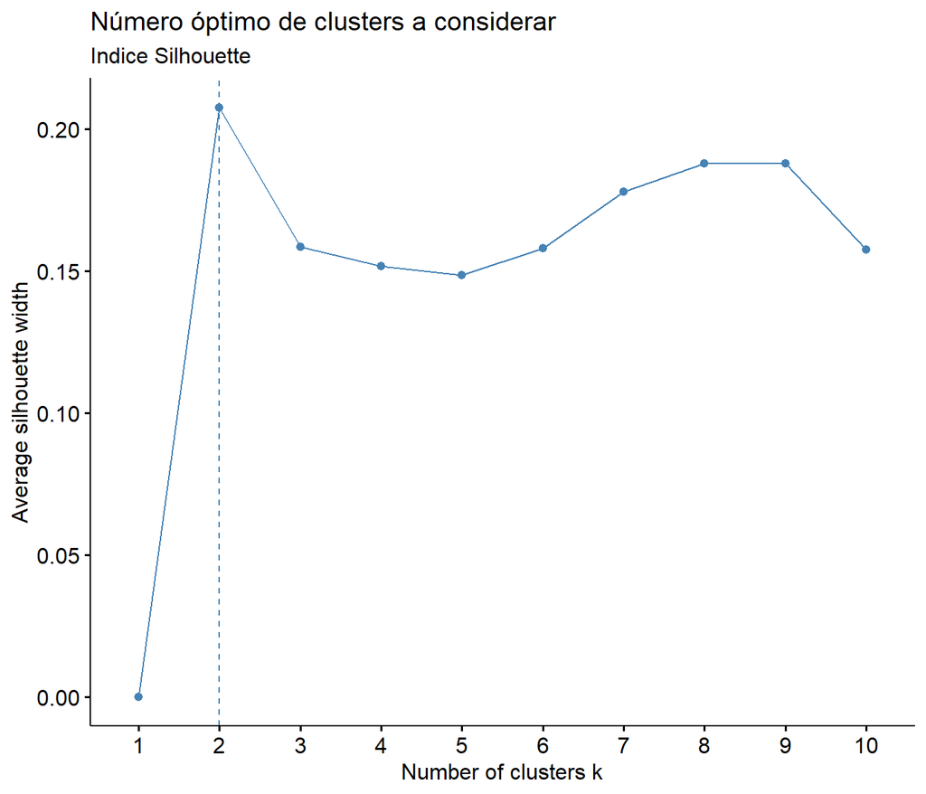

Figure 5.1: Indice de Silhouette segun el numero de clusters a considerar

```r
fviz_nbclust(cardio_numericas_std, kmeans, method = "silhouette") +
  labs(title = "Número óptimo de clusters a considerar",
       subtitle = "Indice Silhouette")
```

Por lo tanto, utilizaremos $k=2$. Esto significa que estamos buscando dos grupos de personas con caracteristicas distintas entre si.

```r
clustering <- kmeans(cardio_numericas_std, centers = 2)

cardio$cluster <- factor(clustering$cluster)
cardio_numericas$cluster <- factor(clustering$cluster)
```

Analizaremos cada variable por cada uno de los clusters generados por kmeans.

|  | variable | cluster | n | mean | median | cv | min | max |
| --- | --- | --- | --- | --- | --- | --- | --- | --- |
| 1 | ct1 | 1 | 26 | 215.192307692308 | 207.5 | 17.9429904328757 | 158 | 293 |
| 2 | ct2 | 2 | 42 | 211.547619047619 | 207.5 | 17.6806595659751 | 143 | 296 |
| 3 | glicemia1 | 1 | 26 | 1.06269230769231 | 1.01 | 19.2086213692384 | 0.79 | 1.65 |
| 4 | glicemia2 | 2 | 42 | 0.950952380952381 | 0.925 | 15.6901846455802 | 0.68 | 1.33 |
| 5 | hdl1 | 1 | 26 | 52.6538461538462 | 50 | 26.6209759847935 | 27 | 93 |
| 6 | hdl2 | 2 | 42 | 59.8809523809524 | 58.5 | 24.7373894300872 | 24 | 90 |
| 7 | hto1 | 1 | 26 | 44.3538461538462 | 44 | 8.4866849187729 | 38.3 | 52.2 |
| 8 | hto2 | 2 | 42 | 40.4857142857143 | 40.35 | 11.3475609271702 | 28.2 | 52.2 |
| 9 | imc1 | 1 | 26 | 34.1843377074148 | 33.0900654455203 | 12.7265539111337 | 29.3360954258412 | 45.5411139697284 |
| 10 | imc2 | 2 | 42 | 26.2343664858473 | 26.346494034401 | 8.90235635935427 | 21.9075824577062 | 31.2973739547166 |

[output cut: 4 more lines]

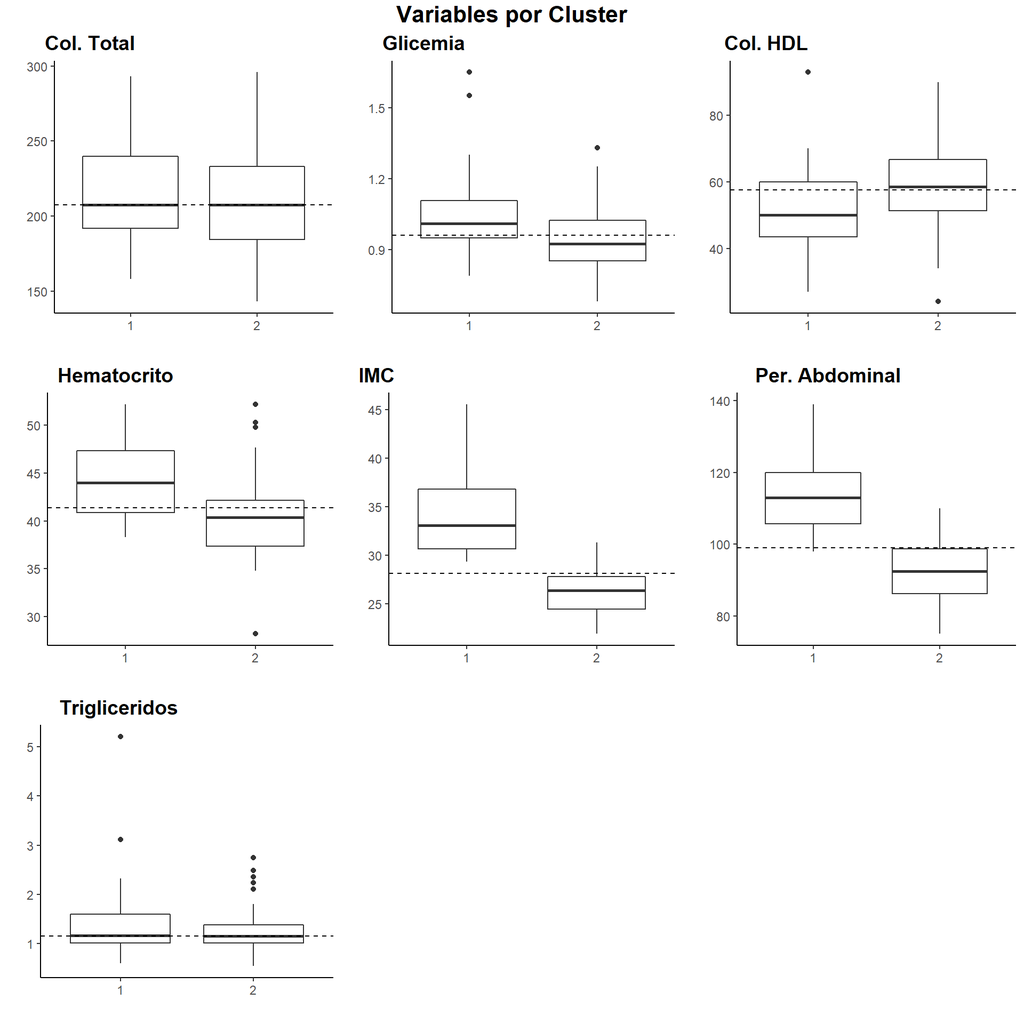

Figure 5.2: Boxplot de variables por cluster

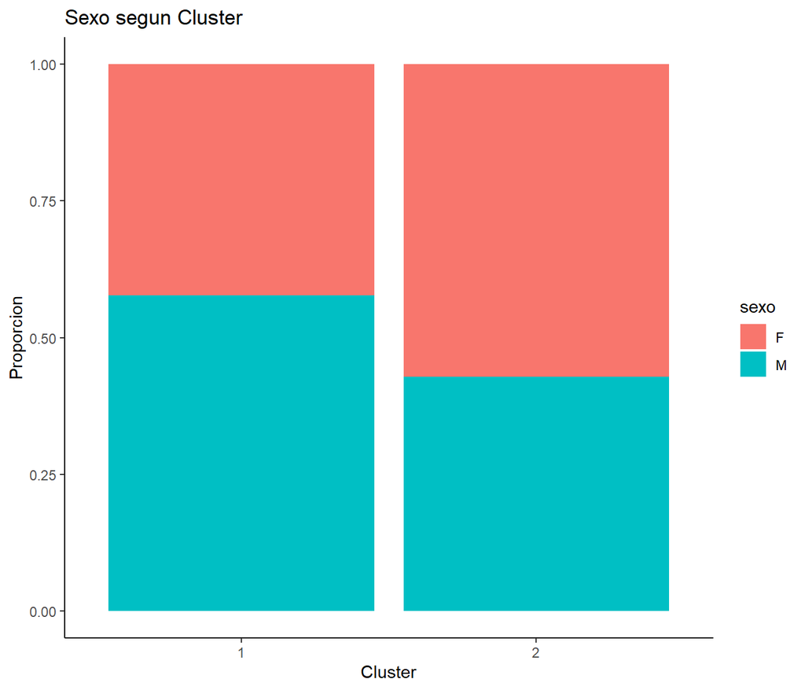

Figure 5.3: Sexo segun Cluster

De los datos y graficos podemos determinar lo siguiente:

**Cluster 1**:

- *Colesterol total:* mediana igual a la global, con un valor de `207.50mg/dL`.
- *Glicemia:* mediana por encima de la global, con un valor de `1.01mg/dL`.
- *Colesterol HD:* mediana por debajo de la global, con un valor de `50.00mg/dL`.
- *Hematocrito:* mediana por encima de la global, con un valor de `44.00%`.
- *IMC:* mediana muy por encima de la global, con un valor de `33.09kg/m2`.
- *Perimetro Abdominal:* mediana muy por encima de la global, con un valor de `113.00cm`.
- *Trigliceridos:* mediana similar a la global, con un valor de `1.16mg/dL`.
- *Sexo:* en su mayoria hombres.

*Posible nombre:* “Personas con sobrepeso”

**Cluster 2**:

- *Colesterol total:* mediana igual a la global, con un valor de `207.50mg/dL`.
- *Glicemia:* mediana por debajo de la global, con un valor de `0.93mg/dL`.
- *Colesterol HDL:* mediana similar a la global, con un valor de `58.50mg/dL`.
- *Hematocrito:* mediana por debajo de la global, con un valor de `40.35%`.
- *IMC:* mediana por debajo de la global, con un valor de `26.35kg/m2`.
- *Perimetro Abdominal:* mediana por debajo de la global, con un valor de `92.50cm`.
- *Trigliceridos:* mediana similar a la global, con un valor de `1.15mg/dL`.
- *Sexo:* en su mayoria mujeres.

*Posible nombre:* “Personas con peso saludable”

Resumiendo:

| Variable | Cluster 1 | Cluster 2 |
| --- | --- | --- |
| Colesterol total | Medio | Medio |
| Glicemia | Alto | Medio-Bajo |
| Colesterol hdl | Bajo | Medio |
| Hematocrito | Alto | Medio-Bajo |
| Indice de masa corporal | Alto | Bajo |
| Perimetro abdominal | Alto | Bajo |
| Trigliceridos | Medio-Alto | Medio |

# 6 Clasificacion

*Construya la variable dicotómica ‘obesidad’ (índice de masa corporal mayor a 30) y construya un modelo predictivo utilizando sólo el sexo del paciente y las variables de los resultados de las pruebas de laboratorio (hematocrito, glicemia, colesterol Total, colesterol HDL y triglicéridos). ¿Qué capacidad predictiva tiene ese modelo?*

Agregamos la variable `obesidad` y filtramos por las del laboratorio:

```r
cardio_clasificacion %>%
  format_table('Variables para realizar la clasificacion')
```

|  | sexo_m | hto | glicemia | ct | hdl | tgd | obesidad |
| --- | --- | --- | --- | --- | --- | --- | --- |
| 1 | 0 | 35 | 1.18 | 225 | 75 | 2.1 | 0 |
| 2 | 1 | 43.5 | 0.93 | 293 | 37 | 5.21 | 0 |
| 3 | 0 | 39.1 | 0.87 | 197 | 54 | 1.3 | 0 |
| 4 | 0 | 42.8 | 0.73 | 282 | 57 | 1.18 | 1 |
| 5 | 1 | 41.1 | 0.98 | 154 | 24 | 1.26 | 0 |
| 6 | 0 | 40.6 | 0.99 | 222 | 58 | 1.09 | 1 |
| 7 | 0 | 38.5 | 1.33 | 230 | 60 | 0.99 | 0 |
| 8 | 0 | 41.6 | 0.83 | 195 | 60 | 1.15 | 1 |
| 9 | 0 | 43.9 | 0.96 | 220 | 57 | 1.44 | 0 |
| 10 | 1 | 35.4 | 1.15 | 193 | 54 | 0.92 | 0 |

[output cut: 58 more lines]

Como todo problema de entrenamiento supervisado, separamos el dataset en 70% de train y 30% de test.

```r
partition <- createDataPartition(y = cardio_clasificacion$obesidad, p = 0.7, list = FALSE)

train_data <- cardio_clasificacion[partition, ]
test_data <- cardio_clasificacion[-partition, ]
```

*Eleccion del Modelo*

Utilizaremos arboles de decision para poder predecir la variable `obesidad`. La idea de los arboles de decision es que dado un conjunto de datos, fabricar diagramas logicos que sirven para representar y categorizar una serie de condiciones que ocurren de manera sucesiva para la resolucion del problema. Son muy similares a los sistemas basados en reglas.

Implementaremos mediante `caret` arboles `CART` y validacion cruzada o `k-folds`. Este ultimo consiste en tomar los datos originales y crear un conjunto de entrenamiento-prueba y uno de validacion. Durante cada entrenamiento, se tomara un conjunto de entrenamiento y validacion distinto.

Visualmente:

| Iteracion | Dataset |  |  |  |  |
| --- | --- | --- | --- | --- | --- |
| Iteracion 1 | Test | Train |  |  |  |
| Iteracion 2 | Train | Test | Train |  |  |
| Iteracion 3 | Train |  | Test | Train |  |
| Iteracion 4 | Train |  |  | Test | Train |
| Iteracion 5 | Train |  |  |  | Test |

Los arboles CART poseen como hiperparametro el `cp` (Complexity Parameter), que controla el tamaño del arbol. Si el costo de agregar otra variable al arbol desde el nodo actual es mayor al valor de `cp`, entonces la construccion del arbol no continua.

```r
caret_control <- trainControl(method = "repeatedcv",
                              number = 5,
                              repeats = 5)

tree <- train(obesidad ~ .,
              data = train_data,
              method = "rpart",
              trControl = caret_control,
              tuneLength = 10)

tree
```

```
## CART
##
## 49 samples
##  6 predictor
##  2 classes: '0', '1'
##
## No pre-processing
## Resampling: Cross-Validated (5 fold, repeated 5 times)
## Summary of sample sizes: 39, 38, 40, 40, 39, 39, ...
## Resampling results across tuning parameters:
##
##   cp          Accuracy   Kappa
##   0.00000000  0.6173333  0.1895376
##   0.03086420  0.6173333  0.1895376
##   0.06172840  0.6173333  0.1895376
##   0.09259259  0.6136970  0.1636977
##   0.12345679  0.6136970  0.1636977
##   0.15432099  0.6104242  0.1497706
##   0.18518519  0.6104242  0.1497706
##   0.21604938  0.6024242  0.1264372
##   0.24691358  0.6024242  0.1264372
##   0.27777778  0.6126465  0.0782181
##
## Accuracy was used to select the optimal model using the largest value.
## The final value used for the model was cp = 0.0617284.
```

Visualizaremos el mejor arbol obtenido:

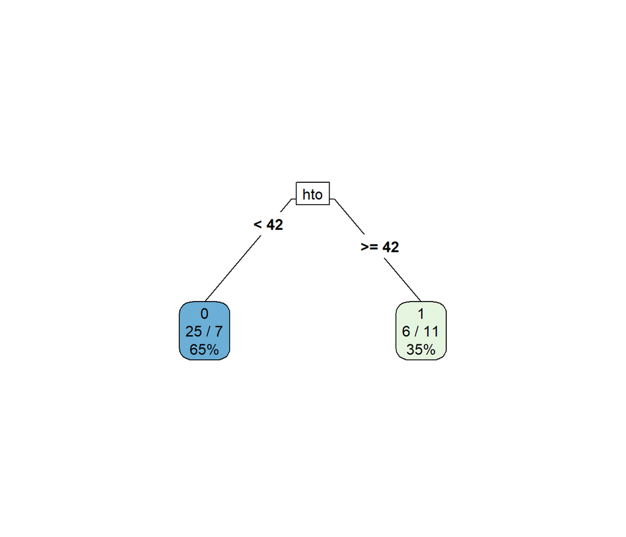

Figure 6.1: Arbol CART obtenido

```r
prp(tree$finalModel, extra = 101, type = 5, xsep = " / ", box.palette = "auto")
```

Para determinar que tan bueno es nuestro arbol, utilizaremos la curva ROC y calcularemos el AUC.

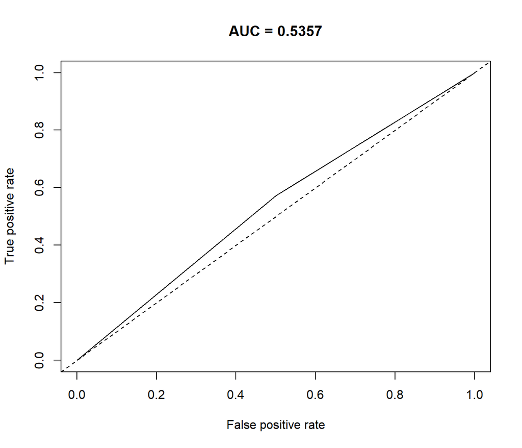

Figure 6.2: Curva ROC del mejor arbol obtenido

```r
predictions <- as.vector(predict(tree$finalModel, newdata = test_data, type = "class"))
mdl_auc <- auc(actual = test_data$obesidad, predicted = predictions)

pred <- prediction(predict(tree$finalModel,
                           type = "prob",
                           newdata = test_data)[, 2],
                   test_data$obesidad)
plot(performance(pred, "tpr", "fpr"), main = paste0("AUC = ", round(mdl_auc, 4)))
abline(0, 1, lty = 2)
```

El arbol obtenido posee un AUC de 0.5357143.